# STAA57 Project

Chun Kang Lu 1008161150

2023-03-24

# About the Dataset

Available [here](https://open.toronto.ca/dataset/covid-19-cases-in-toronto/), the COVID-19 Cases dataset provides weekly updating information about all reported cases of COVID-19 by the Toronto Public Health since the first reported case in January of 2020. The information in this dataset changes every week as new information get updated at 8:30 AM every Tuesday. For consistency in our analysis, we will be using the downloaded `.csv` version of this dataset from March 24 in this report.

This dataset contains 15 columns and 394761 rows, with each row representing a reported individual with COVID-19.

The columns are as follows:

- `_id` - A unique row identifier for Open Data database.
- `Assigned_ID` - A unique ID assigned to cases by Toronto Public Health for the purposes of posting to Open Data, to allow for tracking of specific cases.
- `Outbreak Associated` - Cases associated with outbreaks are identified by their settings and institutions (eg. long-term care homes, retirement homes, hospitals, homeless shelters, etc.).
- `Age Group` - Age at time of illness. Age groups (in years): ≤19, 20-29, 30-39, 40-49, 50-59, 60-69, 70-79, 80-89, 90+, unknown (blank)
- `Neighbourhood Name` - Toronto is divided into 140 geographically distinct neighborhoods that were established to help government and community agencies with local planning by providing socio-economic data for a meaningful geographic area.
- `FSA` - Forward sortation area (i.e. first three characters of postal code) based on the case’s primary home address.
- `Source of Infection` - The most likely way the person contracted COVID-19. These are determined through a few factors of a public health investigator’s assessment, association with a confirmed COVID-19 outbreak, and known risk factors (like travel or close contact with another known COVID-19 case).
- `Classification` - Categorization of the cases as confirmed or probable, according to standard criteria of the Ontario Ministry of Health.
- `Episode Date` - Best estimate to when the disease was first acquired.
- `Reported Date` - Date which the case was reported to Toronto Public Health.
- `Client Gender` - Self-reported gender of the individual.
- `Outcome` - 3 scenarios of fatal, resolved, and active. - Fatal means the individual has died directly due to COVID-19 and not an alternative cause of death. - Resolved refers to individuals who have either: - Been marked Fatal but the cause of death was not due to COVID-19. - Are alive and has been more than 14 days from the episode date and the case is not currently hospitalized, intubated, or in ICU. - Active refers to all other ongoing cases
- `Ever Hospitalized` - Cases that were hospitalized related to their COVID-19 infection (includes cases that are currently hospitalized and those that have been discharged or are deceased).
- `Ever in ICU` - Cases that were admitted to the intensive care unit (ICU) related to their COVID-19 infection (includes cases that are currently in ICU and those that have been discharged or are deceased).
- `Ever Intubated` - Cases that were intubated related to their COVID-19 infection (includes cases that are currently intubated and those that have been discharged or deceased)

# Main Question

We sought to examine what factors seemed to be the most prevalent among cases who are classified *FATAL* as these could serve as predictors for which portion of the population COVID-19 is most dangerous towards.

# Preliminary Analysis

We chose to discard *ACTIVE* cases as these are people who have COVID-19 at the time of obtaining this CSV file, and we are unable to know if they will become *RESOLVED* or *FATAL* in the future.

| Age.Group | TotalCases | deathRate |
| --- | --- | --- |
| 90 and older | 10810 | 0.1193340 |
| 80 to 89 Years | 18308 | 0.0882128 |
| 70 to 79 Years | 20653 | 0.0462403 |
| 60 to 69 Years | 33369 | 0.0175312 |
| 50 to 59 Years | 51253 | 0.0045071 |
| 40 to 49 Years | 55909 | 0.0014667 |
| 30 to 39 Years | 72173 | 0.0005127 |
| 19 and younger | 54337 | 0.0001104 |
| 20 to 29 Years | 76618 | 0.0001044 |

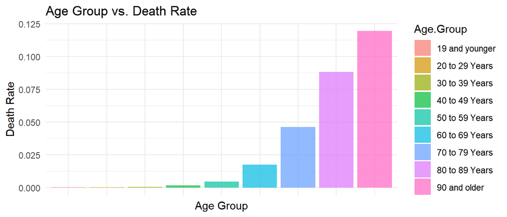

| Client.Gender | TotalCases | deathRate |
| --- | --- | --- |
| MALE | 180963 | 0.0141355 |
| UNKNOWN | 3583 | 0.0128384 |
| FEMALE | 208602 | 0.0105704 |
| NON-BINARY | 186 | 0.0000000 |
| NOT LISTED, PLEASE SPECIFY | 4 | 0.0000000 |
| OTHER | 14 | 0.0000000 |
| TRANS MAN | 29 | 0.0000000 |
| TRANS WOMAN | 25 | 0.0000000 |
| TRANSGENDER | 24 | 0.0000000 |

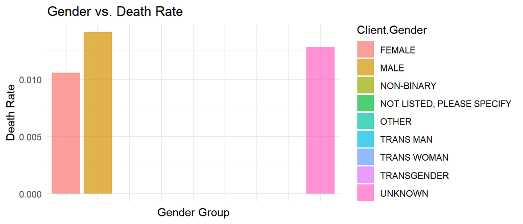

| Client.Gender | Age.Group | TotalCases | deathRate |
| --- | --- | --- | --- |
| UNKNOWN | 90 and older | 31 | 0.4193548 |
| UNKNOWN | 80 to 89 Years | 53 | 0.2452830 |
| MALE | 90 and older | 3306 | 0.1454930 |
| MALE | 80 to 89 Years | 7732 | 0.1122607 |
| FEMALE | 90 and older | 7473 | 0.1065168 |
| FEMALE | 80 to 89 Years | 10523 | 0.0697520 |
| MALE | 70 to 79 Years | 10385 | 0.0581608 |
| FEMALE | 70 to 79 Years | 10179 | 0.0342863 |
| UNKNOWN | 70 to 79 Years | 87 | 0.0229885 |
| MALE | 60 to 69 Years | 16362 | 0.0229801 |

| location | TotalCases |
| --- | --- |
| M1B - Malvern | 7072 |
| M9V - Mount Olive-Silverstone-Jamestown | 6460 |
| M3J - York University Heights | 5285 |
| M5V - Waterfront Communities-The Island | 4999 |
| M2R - Westminster-Branson | 4934 |
| M1P - Dorset Park | 4473 |
| M3N - Black Creek | 4293 |
| M9W - West Humber-Clairville | 4288 |
| M1G - Woburn | 4218 |
| M3A - Parkwoods-Donalda | 4191 |

| Outbreak.Associated | TotalCases | deathRate |
| --- | --- | --- |
| Outbreak Associated | 48067 | 0.0472049 |
| Sporadic | 345363 | 0.0073546 |

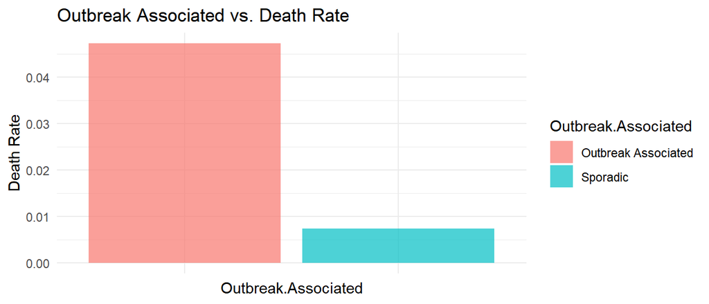

| Source.of.Infection | TotalCases | deathRate |
| --- | --- | --- |
| No Information | 195525 | 0.0055645 |
| Community | 80602 | 0.0123198 |
| Household Contact | 42499 | 0.0056943 |
| Outbreaks, Healthcare Institutions | 32110 | 0.0685456 |
| Close Contact | 20613 | 0.0076651 |
| Outbreaks, Other Settings | 11689 | 0.0044486 |
| Outbreaks, Congregate Settings | 5607 | 0.0062422 |
| Travel | 4733 | 0.0076062 |
| Pending | 52 | 0.0769231 |

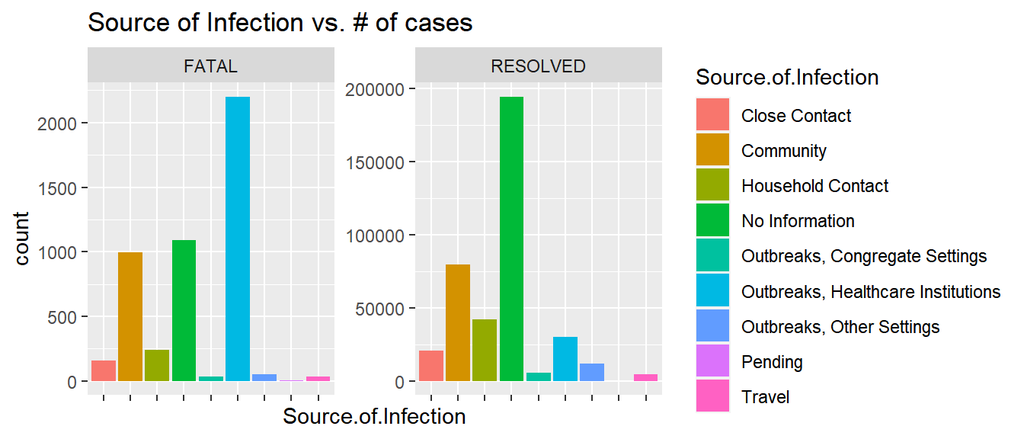

| Ever.Hospitalized | TotalCases | deathRate |
| --- | --- | --- |
| Yes | 17126 | 0.1849819 |
| No | 376304 | 0.0043608 |

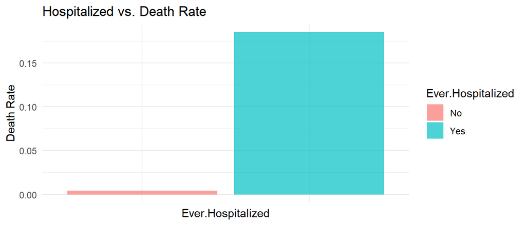

| Ever.in.ICU | TotalCases | deathRate |
| --- | --- | --- |
| Yes | 2900 | 0.3975862 |
| No | 14226 | 0.1416421 |

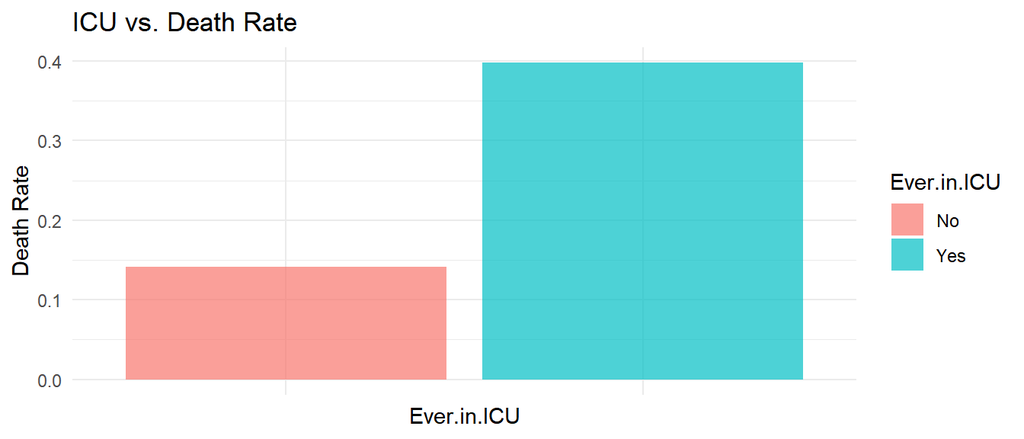

| Ever.Intubated | TotalCases | deathRate |
| --- | --- | --- |
| Yes | 1674 | 0.4958184 |
| No | 1226 | 0.2634584 |

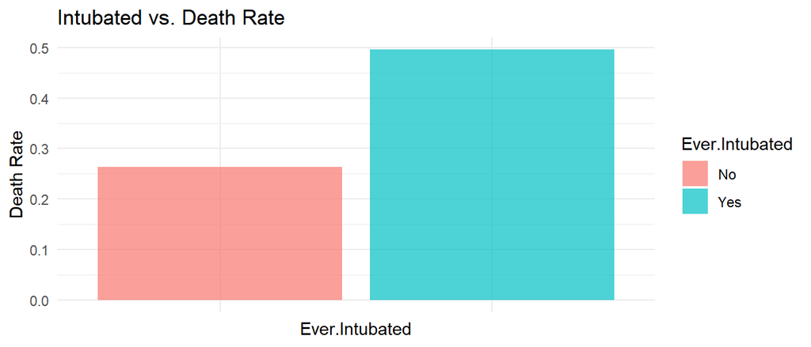

# Regression Analysis

As we can see from the figure below, there are magnitudes more RESOLVED cases than FATAL cases, creating a really imbalanced dataset.

| Outcome | Count |
| --- | --- |
| FATAL | 4809 |
| RESOLVED | 388621 |

From such, we use boostrapping to oversample the FATAL cases and undersample the RESOLVED cases to create a more balanced dataset and allow for our logistic regression model to fit to the data.

We can also use this opportunity to test the correlation between the each independent variable and their Outcome, as well as examine the confidence interval of the correlation.

```
##
## Call:
## glm(formula = out ~ Outbreak.Associated + Age.Group + Client.Gender +
##     Ever.Hospitalized + Ever.in.ICU + Ever.Intubated, family = binomial,
##     data = boot_data)
##
## Deviance Residuals:
##     Min       1Q   Median       3Q      Max
## -3.6388  -0.1912  -0.0251   0.2604   3.4888
##
## Coefficients:
##                             Estimate Std. Error z value Pr(>|z|)
## (Intercept)                 -4.49871    0.42407 -10.608  < 2e-16 ***
## Outbreak.AssociatedSporadic -1.58498    0.07181 -22.072  < 2e-16 ***
## Age.Group20 to 29 Years      0.34437    0.52468   0.656  0.51160
## Age.Group30 to 39 Years      1.39118    0.45546   3.054  0.00225 **
## Age.Group40 to 49 Years      2.21887    0.44188   5.021 5.13e-07 ***
## Age.Group50 to 59 Years      3.12796    0.43016   7.272 3.55e-13 ***
## Age.Group60 to 69 Years      4.03796    0.42685   9.460  < 2e-16 ***
## Age.Group70 to 79 Years      5.04258    0.42556  11.849  < 2e-16 ***
## Age.Group80 to 89 Years      5.93513    0.42510  13.962  < 2e-16 ***
## Age.Group90 and older        6.54917    0.42906  15.264  < 2e-16 ***
## Client.GenderMALE            0.50610    0.06708   7.544 4.54e-14 ***
## Ever.HospitalizedYes         3.12492    0.09098  34.347  < 2e-16 ***
## Ever.in.ICUYes               1.78208    0.25987   6.858 7.01e-12 ***
## Ever.IntubatedYes            1.35474    0.34484   3.929 8.54e-05 ***
## ---
## Signif. codes:  0 '***' 0.001 '**' 0.01 '*' 0.05 '.' 0.1 ' ' 1
##
## (Dispersion parameter for binomial family taken to be 1)
##
##     Null deviance: 22180.7  on 15999  degrees of freedom
## Residual deviance:  6545.1  on 15986  degrees of freedom
## AIC: 6573.1
##
## Number of Fisher Scoring iterations: 7
```

Following analysis on prior tables and graphs, we can see that FATAL cases are most prevalent in those who were in an outbreak, older age, male, as well as being hospitalized in ICU, being intubated. The highest correlation being those in the Age Group of 90 and older as that category contains the hightest log-odds at 6.54917 with respect to a FATAL outcome out of all variables.

Since p-values for all categories aside from *Age Group 20 to 29 Years* are very low, we can safely reject the null hypothesis in that those categories have zero correlation to the *Outcome* of the case. We can similarly obtain this conclusion by seeing that 0 is not within the confidence intervals of these categories.

```
##                                  2.5 %     97.5 %
## (Intercept)                 -5.4473922 -3.7556329
## Outbreak.AssociatedSporadic -1.7261080 -1.4445823
## Age.Group20 to 29 Years     -0.6579384  1.4401986
## Age.Group30 to 39 Years      0.5697437  2.3864762
## Age.Group40 to 49 Years      1.4315476  3.1940199
## Age.Group50 to 59 Years      2.3696913  4.0856592
## Age.Group60 to 69 Years      3.2878123  4.9906873
## Age.Group70 to 79 Years      4.2957264  5.9934429
## Age.Group80 to 89 Years      5.1894866  6.8853377
## Age.Group90 and older        5.7940888  7.5054180
## Client.GenderMALE            0.3749579  0.6379655
## Ever.HospitalizedYes         2.9487903  3.3055350
## Ever.in.ICUYes               1.2945104  2.3165144
## Ever.IntubatedYes            0.6784200  2.0386924
```

# Model Prediction Accuracy

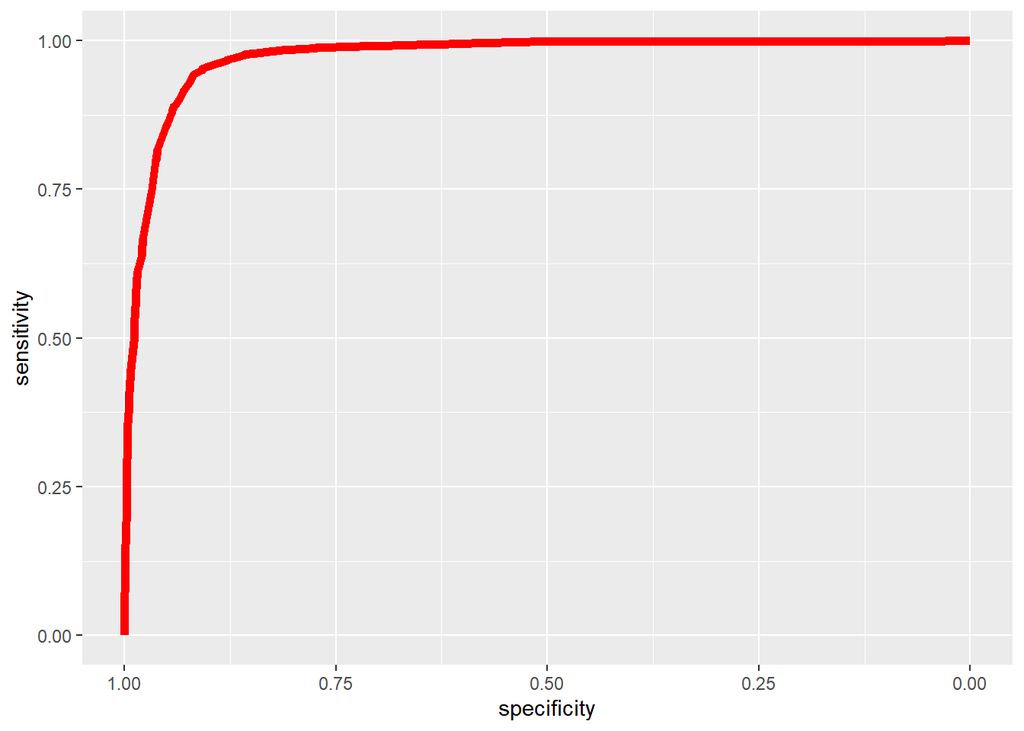

```
## Area under the curve: 0.9734
```

The model performs very well. Choosing a cutoff point of 0.9, we get the following confusion matrix.

```
##
##        0    1
##   0 2368   50
##   1  834 1528
```

And and overall accuracy of:

```
## [1] 0.8150628
```

# Results

The COVID-19 pandemic has affected people of all ages and genders across the world, and people are striving to develop effective public health strategies to combat the COVID-19 pandemic. To achieve this, we need to understand how factors such as age, gender, and exposure to outbreaks can affect the death and resolution rates of COVID-19 patients.

Additionally, individuals requiring hospitalization, ICU admission, or intubation have a higher death rate. This is not surprising, as these cases typically represent more severe forms of the disease. When examining hospitalized cases, the death rate is higher among those who were admitted to the ICU or required intubation than those who were not. These observations imply that early medical intervention and hospitalization could be vital in enhancing the chances of recovery from COVID-19.

# Appendix

```r
library(tidyverse)
library(knitr)
library(gridExtra)
library(kableExtra)
library(pROC)
library(leaflet)
# We have to note the data was downloaded on March 24, and the dataset is updated every week, so future downloads may get slightly different results.
data = read.csv("COVID19 cases.csv")
# Turn Episode.Date and Reported.Date into Date type
data = data %>% mutate(Episode.Date = as.Date(Episode.Date, format = "%Y-%m-%d"),
                       Reported.Date = as.Date(Reported.Date, format = "%Y-%m-%d"))
data = data %>% filter(Age.Group != "")
main_data = data %>% filter(Outcome!="ACTIVE") %>% select(-c(X_id, Assigned_ID))
gen_filtered = main_data %>% filter(Client.Gender %in% c("MALE", "FEMALE"))
```

```r
# Tables & Graphs
# Relation between Age and death rate
data_byAge = main_data %>% filter(Age.Group != "") %>% group_by(Age.Group) %>% summarise(TotalCases=n(), deathRate = mean(Outcome == "FATAL"))%>%arrange(desc(deathRate))

kbl(data_byAge) %>%
    kable_styling(full_width = F, font_size = 10)

ggplot(data_byAge, aes(x = Age.Group, y = deathRate, fill=Age.Group)) +
  geom_bar(stat = "identity", alpha = 0.7) +
  labs(title = "Age Group vs. Death Rate", x = "Age Group", y = "Death Rate") +
  theme_minimal()+
  theme(axis.text.x=element_blank())
```

```r
# Relation between Gender and death rate
data_byGender = main_data %>% filter(Client.Gender!="") %>% group_by(Client.Gender)%>%summarise( TotalCases=n(),deathRate = mean(Outcome == "FATAL"))%>%arrange(desc(deathRate))

kbl(data_byGender) %>%
    kable_styling(full_width = F, font_size = 10)

ggplot(data_byGender, aes(x = Client.Gender, y = deathRate, fill=Client.Gender)) +
  geom_bar(stat = "identity", alpha = 0.7) +
  labs(title = "Gender vs. Death Rate", x = "Gender Group", y = "Death Rate") +
  theme_minimal()+
  theme(axis.text.x=element_blank())
```

```r
# Relation between gender and age vs. death rate
data_byGender_Age = main_data %>% filter(Client.Gender!="") %>% group_by(Client.Gender,Age.Group)%>%summarise( TotalCases=n(),deathRate = mean(Outcome == "FATAL")) %>% arrange(desc(deathRate))
kbl(data_byGender_Age[1:10,]) %>%
    kable_styling(full_width = F, font_size = 10)

#Relation between location and total case
data_byLocation  = main_data %>% filter(FSA != "") %>%filter(Neighbourhood.Name != "")%>% mutate(location = paste(FSA, Neighbourhood.Name, sep = " - "))%>% group_by(location) %>% summarise(TotalCases=n())

topCaseLocation = data_byLocation %>% arrange(desc(TotalCases))
kbl(topCaseLocation[1:10,]) %>%
    kable_styling(full_width = F, font_size = 10)
```

```r
# Relation between Outbreak Associated and death rate
data_byOutbreakAssociated = main_data %>% filter(Outbreak.Associated!="") %>% group_by(Outbreak.Associated)%>%summarise( TotalCases=n(), deathRate = mean(Outcome == "FATAL"))%>% arrange(desc(deathRate))

kbl(data_byOutbreakAssociated) %>%
    kable_styling(full_width = F, font_size = 10)

ggplot(data_byOutbreakAssociated, aes(x = Outbreak.Associated, y = deathRate, fill=Outbreak.Associated)) +
  geom_bar(stat = "identity", alpha = 0.7) +
  labs(title = "Outbreak Associated vs. Death Rate", x = "Outbreak.Associated", y = "Death Rate") +
  theme_minimal()+
  theme(axis.text.x=element_blank())
```

```r
# Relation between Source of Infection and Number of cases
data_byInfection = main_data %>% filter(Source.of.Infection!="") %>% group_by(Source.of.Infection)%>%summarise( TotalCases=n(), deathRate = mean(Outcome == "FATAL"))%>% arrange(desc(TotalCases))

kbl(data_byInfection %>% arrange(desc(TotalCases))) %>%
    kable_styling(full_width = F, font_size = 10)

ggplot(main_data, aes(x=Source.of.Infection, fill=Source.of.Infection)) +
    geom_bar(position = "dodge") +
    facet_wrap(~Outcome, scales="free_y") +
    labs(title = "Source of Infection vs. # of cases")+
    theme(axis.text.x=element_blank())
```

```r
# Relation between hospitalized and death rate
data_byHospitalized = main_data %>% filter(Ever.Hospitalized!="") %>% group_by(Ever.Hospitalized)%>%summarise( TotalCases=n(),deathRate = mean(Outcome == "FATAL")) %>%arrange(desc(deathRate))

kbl(data_byHospitalized %>% arrange(desc(deathRate))) %>%
    kable_styling(full_width = F, font_size = 10)

ggplot(data_byHospitalized, aes(x = Ever.Hospitalized, y = deathRate, fill=Ever.Hospitalized)) +
  geom_bar(stat = "identity", alpha = 0.7) +
  labs(title = "Hospitalized vs. Death Rate", x = "Ever.Hospitalized", y = "Death Rate") +
  theme_minimal()+
  theme(axis.text.x=element_blank())
```

```r
# Relation between ICU and death rate
# data_check = data %>% filter(Ever.in.ICU =="Yes" && Ever.Hospitalized== "No") gives 0 obs which means in icu must be in hospital
# death rate is computed by only considering the case that Ever.Hospitalized== "Yes"
data_byICU = main_data %>% filter(Ever.in.ICU!="") %>%  filter(Ever.Hospitalized== "Yes") %>% group_by(Ever.in.ICU) %>%         summarise( TotalCases=n(),deathRate = mean(Outcome == "FATAL"))

kbl(data_byICU %>% arrange(desc(deathRate))) %>%
    kable_styling(full_width = F, font_size = 10)

ggplot(data_byICU, aes(x = Ever.in.ICU, y = deathRate, fill=Ever.in.ICU)) +
  geom_bar(stat = "identity", alpha = 0.7) +
  labs(title = "ICU vs. Death Rate", x = "Ever.in.ICU", y = "Death Rate") +
  theme_minimal()+
  theme(axis.text.x=element_blank())
```

```r
# Relation between intubated and death rate
# data_check = data %>% filter(Ever.in.ICU =="No" && Ever.Hospitalized== "Yes") gives 0 obs which means intubated must be in icu
data_byIntubated = main_data %>% filter(Ever.Intubated!="") %>% filter(Ever.in.ICU=="Yes") %>%   group_by(Ever.Intubated)%>%summarise( TotalCases=n(),deathRate = mean(Outcome == "FATAL"))

kbl(data_byIntubated %>% arrange(desc(deathRate))) %>%
    kable_styling(full_width = F, font_size = 10)

ggplot(data_byIntubated, aes(x = Ever.Intubated, y = deathRate, fill=Ever.Intubated)) +
  geom_bar(stat = "identity", alpha = 0.7) +
  labs(title = "Intubated vs. Death Rate", x = "Ever.Intubated", y = "Death Rate") +
  theme_minimal()+
  theme(axis.text.x=element_blank())
```

```r
outcome_count = main_data %>% group_by(Outcome) %>% summarize(Count=n())
kbl(outcome_count) %>%
    kable_styling(full_width = F, font_size = 10)
```

```r
# Regression Analysis
main_res = gen_filtered %>% filter(Outcome=="RESOLVED")
main_fat = gen_filtered %>% filter(Outcome=="FATAL")
set.seed(5)
boot_res = main_res %>% sample_n(8000, replace=T)
boot_fat = main_fat %>% sample_n(8000, replace=T)
boot_data = rbind(boot_res, boot_fat)
boot_data = boot_data %>% mutate(out = ifelse(Outcome == "FATAL", 1, 0))
model = glm(out ~ Outbreak.Associated + Age.Group + Client.Gender +  Ever.Hospitalized + Ever.in.ICU + Ever.Intubated, family=binomial, data = boot_data)
summary(model)
confint(model)
```

```r
# Cross Validation
boot_data = boot_data %>% mutate(group_ind = sample(c("train","test"),
                size=nrow(boot_data),
                prob = c(0.7,0.3),
                replace = T))
train = boot_data %>% filter(group_ind == "train")
test = boot_data %>% filter(group_ind == "test")
model2 = glm(out ~ Outbreak.Associated + Age.Group + Client.Gender + Ever.Hospitalized + Ever.in.ICU + Ever.Intubated,
            family=binomial, data = train)
test = test %>% mutate(pred = predict(model, newdata = test, type="response"))
```

```r
# ROC, AUC and Analysis
roc_logit = roc(test$out ~ test$pred)
ggroc(roc_logit, color="red", size = 2)
auc(roc_logit)
test = test %>% mutate(pred_out = ifelse(pred >= 0.9, 1, 0))
conmat = table(test$out, test$pred_out)
conmat
sum(diag(conmat))/sum(conmat)
```